# 04 - Distance, Knn, Cross Validation, and Generative Models Comprehension Check

Dwaipayan Chatterjee - Harvard Data Science Professional

## **Distance**

### **Question 1**

Load the following dataset:

```r
library(dslabs)
data("tissue_gene_expression")
```

This dataset includes a matrix `x`:

```r
dim(tissue_gene_expression$x)
```

```
## [1] 189 500
```

This matrix has the gene expression levels of 500 genes from 189 biological samples representing seven different tissues. The tissue type is stored in `y`:

```r
table(tissue_gene_expression$y)
```

```
##
##  cerebellum       colon endometrium hippocampus      kidney       liver
##          38          34          15          31          39          26
##    placenta
##           6
```

Which of the following lines of code computes the Euclidean distance between each observation and stores it in the object `d`?

```r
d <- dist(tissue_gene_expression$x)
```

- `d <- dist(tissue_gene_expression$x, distance='maximum')`
- `d <- dist(tissue_gene_expression)`
- `d <- dist(tissue_gene_expression$x)` [X]
- `d <- cor(tissue_gene_expression$x)`

### **Question 2**

Compare the distances between observations 1 and 2 (both cerebellum), observations 39 and 40 (both colon), and observations 73 and 74 (both endometrium).

Distance-wise, are samples from tissues of the same type closer to each other?

```r
ind <- c(1, 2, 39, 40, 73, 74)
as.matrix(d)[ind,ind]
```

```
##               cerebellum_1 cerebellum_2   colon_1   colon_2 endometrium_1
## cerebellum_1      0.000000     7.005922 22.694801 22.699755      21.12763
## cerebellum_2      7.005922     0.000000 22.384821 22.069557      20.87910
## colon_1          22.694801    22.384821  0.000000  8.191935      14.99672
## colon_2          22.699755    22.069557  8.191935  0.000000      14.80355
## endometrium_1    21.127629    20.879099 14.996715 14.803545       0.00000
## endometrium_2    21.780792    20.674802 18.089213 17.004456      14.29405
##               endometrium_2
## cerebellum_1       21.78079
## cerebellum_2       20.67480
## colon_1            18.08921
## colon_2            17.00446
## endometrium_1      14.29405
## endometrium_2       0.00000
```

- No, the samples from the same tissue type are not necessarily closer.
- The two colon samples are closest to each other, but the samples from the other two tissues are not.
- The two cerebellum samples are closest to each other, but the samples from the other two tissues are not.
- Yes, the samples from the same tissue type are closest to each other. [X]

### **Question 3**

Make a plot of all the distances using the `image` function to see if the pattern you observed in Q2 is general.

Which code would correctly make the desired plot?

- `image(d)`
- `image(as.matrix(d))` [X]
- `d`
- `image()`

## **Nearest Neighbors**

### **Question 1**

Previously, we used logistic regression to predict sex based on height. Now we are going to use knn to do the same. Use the code described in these videos to select the `F_1` measure and plot it against `k`. Compare to the `F_1` of about 0.6 we obtained with regression. Set the seed to 1.

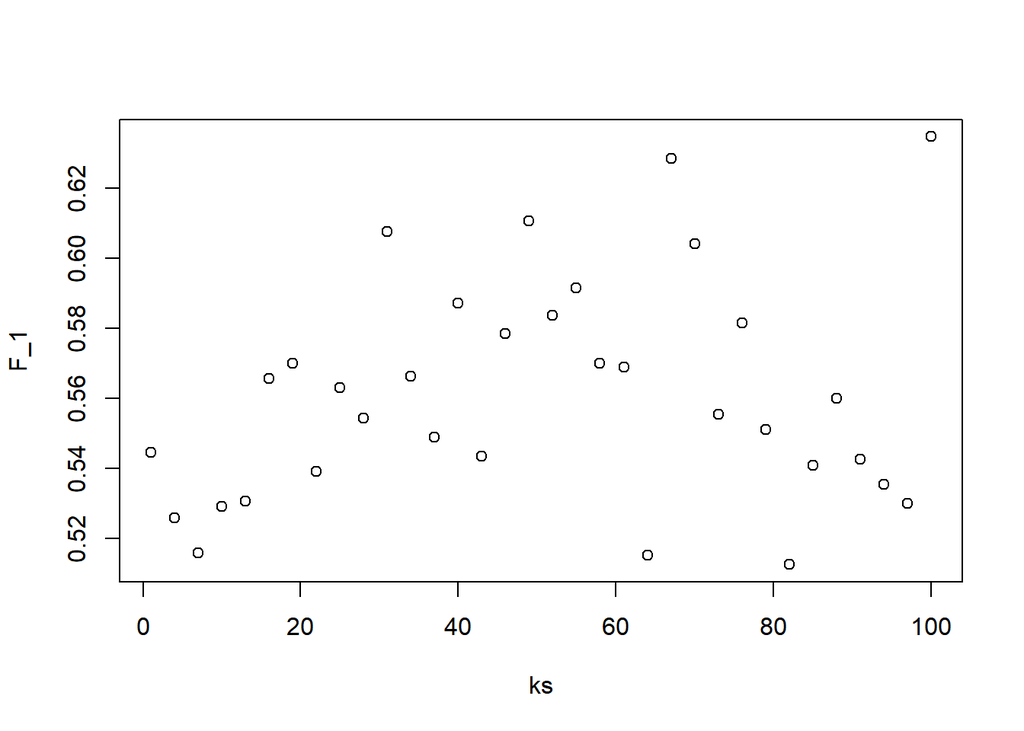

```r
set.seed(1)
data("heights")
library(ggplot2)
library(caret)
library(dplyr)
ks <- seq(1, 101, 3)
F_1 <- sapply(ks, function(k){
    test_index <- createDataPartition(heights$sex, times = 1, p = 0.5, list = FALSE)
    test_set <- heights[test_index, ]
    train_set <- heights[-test_index, ]
    fit <- knn3(sex ~ height, data = train_set, k = k)
    y_hat <- predict(fit, test_set, type = "class") %>%
        factor(levels = levels(train_set$sex))
    F_meas(data = y_hat, reference = test_set$sex)
})
plot(ks, F_1)
```

```r
max(F_1)
```

```
## [1] 0.6347826
```

### **Question 2**

Next we will use the same gene expression example used in the Comprehension Check: Distance exercises. You can load it like this:

```r
library(dslabs)
data("tissue_gene_expression")
```

Split the data into training and test sets, and report the accuracy you obtain. Try it for `k = 1, 3, 5, 7, 9, 11`. Set the seed to 1.

```r
set.seed(1)
library(caret)
y <- tissue_gene_expression$y
x <- tissue_gene_expression$x
train_index <- createDataPartition(y, list = FALSE)
sapply(seq(1, 11, 2), function(k){
    fit <- knn3(x[train_index,], y[train_index], k = k)
    y_hat <- predict(fit, newdata = data.frame(x=x[-train_index,]),
                type = "class")
mean(y_hat == y[-train_index])
})
```

```
## [1] 1.0000000 0.9892473 1.0000000 0.9462366 0.9247312 0.9354839
```

## **Cross-validation**

### **Question 1**

Generate a set of random predictors and outcomes using the following code:

```r
library(dbplyr)
library(dslabs)
library(tidyverse)
library(caret)

set.seed(1996)
n <- 1000
p <- 10000
x <- matrix(rnorm(n*p), n, p)
colnames(x) <- paste("x", 1:ncol(x), sep = "_")
y <- rbinom(n, 1, 0.5) %>% factor()

x_subset <- x[ ,sample(p, 100)]
```

Because `x` and `y` are completely independent, you should not be able to predict `y` using `x` with accuracy greater than 0.5. Confirm this by running cross-validation using logistic regression to fit the model. Because we have so many predictors, we selected a random sample `x_subset`. Use the subset when training the model.

Which code correctly performs this cross-validation?

```r
fit <- train(x_subset, y, method = "glm")
fit$results
```

```
##   parameter  Accuracy       Kappa AccuracySD    KappaSD
## 1      none 0.5052329 0.009740464 0.02993012 0.06042542
```

```
fit <- train(x_subset, y)
fit$results
```

```
fit <- train(x_subset, y, method = "glm")
fit$results [X]
```

```
fit <- train(y, x_subset, method = "glm")
fit$results
```

```
fit <- test(x_subset, y, method = "glm")
fit$results
```

### **Question 2**

Now, instead of using a random selection of predictors, we are going to search for those that are most predictive of the outcome. We can do this by comparing the values for $\ y = 1$ the group to those in the $\ y = 0$ group, for each predictor, using a t-test. You can do perform this step like this:

```r
library(devtools)
devtools::install_bioc("genefilter")
library(genefilter)
tt <- colttests(x, y)
```

Which of the following lines of code correctly creates a vector of the p-values called `pvals`?

- `pvals <- tt$dm`
- `pvals <- tt$statistic`
- `pvals <- tt`
- `pvals <- tt$p.value` [X]

```r
pvals <- tt$p.value
```

### **Question 3**

Create an index `ind` with the column numbers of the predictors that were “statistically significantly” associated with `y`. Use a p-value cutoff of 0.01 to define “statistically significantly.”

```r
ind <- which(pvals <= 0.01)
length(ind)
```

```
## [1] 108
```

How many predictors survive this cutoff? 108

### **Question 4**

Now re-run the cross-validation after redefinining `x_subset` to be the subset of `x` defined by the columns showing “statistically significant” association with `y`.

```r
x_subset <- x[,ind]
fit <- train(x_subset, y, method = "glm")
fit$results
```

```
##   parameter  Accuracy    Kappa AccuracySD    KappaSD
## 1      none 0.7579661 0.514967 0.01615699 0.03236006
```

### **Question 5**

Re-run the cross-validation again, but this time using kNN. Try out the following grid `k = seq(101, 301, 25)` of tuning parameters. Make a plot of the resulting accuracies.

Which code is correct?

```
fit <- train(x_subset, y, method = "knn", tuneGrid = data.frame(k = seq(101, 301, 25)))
ggplot(fit) [X]
```

```
fit <- train(x_subset, y, method = "knn")
ggplot(fit)
```

```
fit <- train(x_subset, y, method = "knn", tuneGrid = data.frame(k = seq(103, 301, 25)))
ggplot(fit)
```

```
fit <- train(x_subset, y, method = "knn", tuneGrid = data.frame(k = seq(101, 301, 5)))
ggplot(fit)
```

### **Question 6**

In the previous exercises, we see that despite the fact that `x` and `y` are completely independent, we were able to predict `y` with accuracy higher than 70%. We must be doing something wrong then.

### **Question 7**

Use the `train` function to predict tissue from gene expression in the `tissue_gene_expression` dataset. Use kNN.

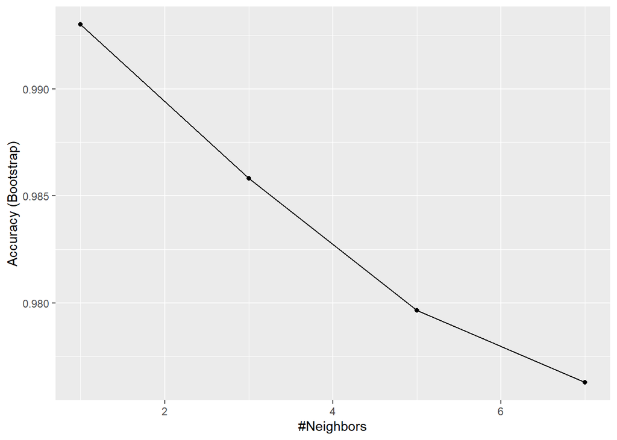

```r
data("tissue_gene_expression")
fit <- with(tissue_gene_expression, train(x, y, method = "knn", tuneGrid = data.frame( k = seq(1, 7, 2))))
ggplot(fit)
```

```r
fit$results
```

```
##   k  Accuracy     Kappa AccuracySD    KappaSD
## 1 1 0.9930099 0.9915503 0.01723884 0.02085401
## 2 3 0.9858200 0.9828828 0.01968015 0.02377410
## 3 5 0.9796566 0.9753574 0.02282353 0.02761332
## 4 7 0.9762775 0.9712238 0.02686113 0.03260885
```

What value of `k` works best? 1

## **Bootstrap**

### **Question 1**

The `createResample` function can be used to create bootstrap samples. For example, we can create 10 bootstrap samples for the `mnist_27` dataset like this:

set.seed(1995) indexes <- createResample(mnist_27$train$y, 10)

How many times do 3, 4, and 7 appear in the first resampled index?

```r
library(caret)
set.seed(1995)
indexes <- createResample(mnist_27$train$y, 10)
sum(indexes[[1]] == 3)
```

```
## [1] 1
```

```r
sum(indexes[[1]] == 4)
```

```
## [1] 2
```

```r
sum(indexes[[1]] == 7)
```

```
## [1] 1
```

### **Question 2**

We see that some numbers appear more than once and others appear no times. This has to be this way for each dataset to be independent. Repeat the exercise for all the resampled indexes.

```r
x=sapply(indexes, function(ind){
    sum(ind == 3)
})
sum(x)
```

```
## [1] 12
```

### **Question 3**

Generate a random dataset using the following code:

```r
set.seed(1)
y <- rnorm(100, 0, 1)
```

Estimate the 75th quantile, which we know is `qnorm(0.75)`, with the sample quantile: `quantile(y, 0.75)`.

Run a Monte Carlo simulation with 10,000 repetitions to learn the expected value and standard error of this random variable. Set the seed to 1.

```r
set.seed(1)
B <- 10000
q_75 <- replicate(B, {
    y <- rnorm(100, 0, 1)
    quantile(y, 0.75)
})

mean(q_75)
```

```
## [1] 0.6656107
```

```r
sd(q_75)
```

```
## [1] 0.1353809
```

### **Question 4**

In practice, we can’t run a Monte Carlo simulation. Use 10 bootstrap samples to estimate the standard error using just the initial sample `y` . Set the seed to 1.

```r
set.seed(1)
indexes <- createResample(y, 10)
q_75_star <- sapply(indexes, function(ind){
    y_star <- y[ind]
    quantile(y_star, 0.75)
})
mean(q_75_star)
```

```
## [1] 0.6712146
```

```r
sd(q_75_star)
```

```
## [1] 0.07858009
```

### **Question 5**

Repeat the exercise from Q4 but with 10,000 bootstrap samples instead of 10. Set the seed to 1.

```r
set.seed(1)
indexes <- createResample(y, 10000)
q_75_star <- sapply(indexes, function(ind){
    y_star <- y[ind]
    quantile(y_star, 0.75)
})
mean(q_75_star)
```

```
## [1] 0.6739372
```

```r
sd(q_75_star)
```

```
## [1] 0.09259491
```

### **Question 6**

Compare the SD values obtained using 10 vs 10,000 bootstrap samples.

What do you observe?

- The SD is substantially lower with 10,000 bootstrap samples than with 10.
- The SD is roughly the same in both cases. [X]
- The SD is substantially higher with 10,000 bootstrap samples than with 10.

## **Generative Models**

In the following exercises, we are going to apply LDA and QDA to the `tissue_gene_expression` dataset. We will start with simple examples based on this dataset and then develop a realistic example.

### **Question 1**

Create a dataset of samples from just cerebellum and hippocampus, two parts of the brain, and a predictor matrix with 10 randomly selected columns using the following code:

```r
set.seed(1993)
data("tissue_gene_expression")
ind <- which(tissue_gene_expression$y %in% c("cerebellum", "hippocampus"))
y <- droplevels(tissue_gene_expression$y[ind])
x <- tissue_gene_expression$x[ind, ]
x <- x[, sample(ncol(x), 10)]
```

Use the train function to estimate the accuracy of LDA.

```r
fit_lda <- train(x, y, method = "lda")
fit_lda$results["Accuracy"]
```

```
##   Accuracy
## 1 0.974834
```

### **Question 2**

In this case, LDA fits two 10-dimensional normal distributions. Look at the fitted model by looking at the `finalModel` component of the result of `train`. Notice there is a component called `means` that includes the estimated means of both distributions. Plot the mean vectors against each other and determine which predictors (genes) appear to be driving the algorithm.

Which TWO genes appear to be driving the algorithm?

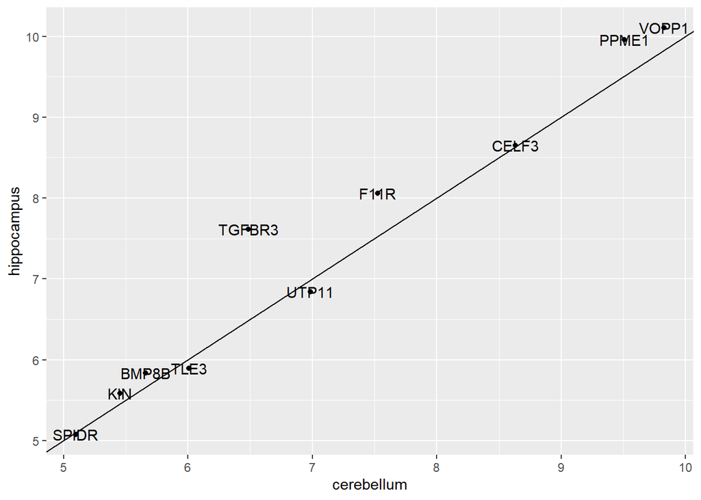

```r
t(fit_lda$finalModel$means) %>% data.frame() %>%
    mutate(predictor_name = rownames(.)) %>%
    ggplot(aes(cerebellum, hippocampus, label = predictor_name)) +
    geom_point() +
    geom_text() +
    geom_abline()
```

### **Question 3**

Repeat the exercise in Q1 with QDA.

Create a dataset of samples from just cerebellum and hippocampus, two parts of the brain, and a predictor matrix with 10 randomly selected columns using the following code:

```r
set.seed(1993)
data("tissue_gene_expression")
ind <- which(tissue_gene_expression$y %in% c("cerebellum", "hippocampus"))
y <- droplevels(tissue_gene_expression$y[ind])
x <- tissue_gene_expression$x[ind, ]
x <- x[, sample(ncol(x), 10)]
```

Use the train function to estimate the accuracy of QDA.

```r
fit_qda <- train(x, y, method = "qda")
fit_qda$results["Accuracy"]
```

```
##    Accuracy
## 1 0.9256166
```

### **Question 4**

Which TWO genes drive the algorithm when using QDA instead of LDA?

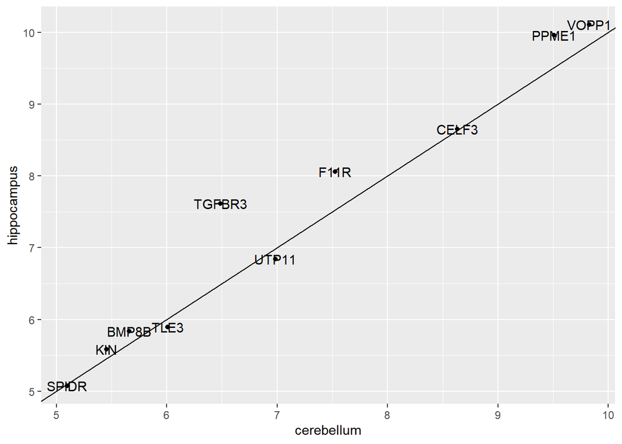

```r
t(fit_qda$finalModel$means) %>% data.frame() %>%
    mutate(predictor_name = rownames(.)) %>%
    ggplot(aes(cerebellum, hippocampus, label = predictor_name)) +
    geom_point() +
    geom_text() +
    geom_abline()
```

### **Question 5**

Which TWO genes drive the algorithm after performing the scaling?

```r
fit_lda <- train(x, y, method = "lda", preProcess = "center")
fit_lda$results["Accuracy"]
```

```
##    Accuracy
## 1 0.9800666
```

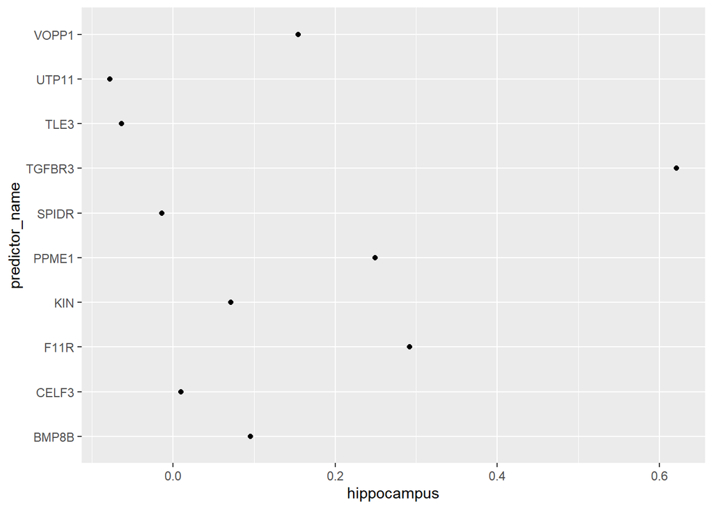

```r
t(fit_lda$finalModel$means) %>% data.frame() %>%
    mutate(predictor_name = rownames(.)) %>%
    ggplot(aes(predictor_name, hippocampus)) +
    geom_point() +
    coord_flip()
```

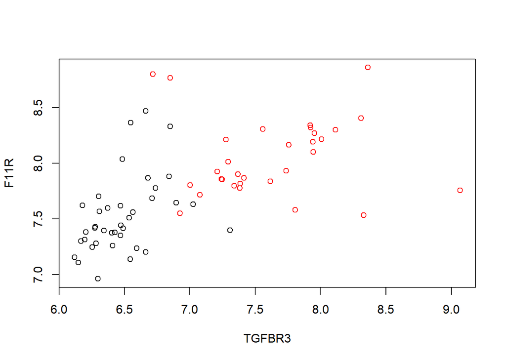

```r
d <- apply(fit_lda$finalModel$means, 2, diff)
ind <- order(abs(d), decreasing = TRUE)[1:2]
plot(x[, ind], col = y)
```

### **Question 6**

Now we are going to increase the complexity of the challenge slightly: we will consider all the tissue types. Use the following code to create your dataset:

```r
set.seed(1993)
data("tissue_gene_expression")
y <- tissue_gene_expression$y
x <- tissue_gene_expression$x
x <- x[, sample(ncol(x), 10)]


fit_lda <- train(x, y, method = "lda", preProcess = c("center"))
fit_lda$results["Accuracy"]
```

```
##    Accuracy
## 1 0.8714486
```